# EasyVisa_Full_Code_Notebook (1)

### Model building with Original data

** Decision Tree (Original Data) **

```python
d_tree = DecisionTreeClassifier(class_weight = 'balanced', random_state=1)
d_tree.fit(X_train,y_train)
```

```
DecisionTreeClassifier(class_weight='balanced', random_state=1)
```

```python
#print(classification_report(y_test, d_tree.predict(X_test), target_names=["Denied","Certified"]))
print (classification_report(y_train, d_tree.predict(X_train), target_names=["Denied","Certified"]))
```

```
              precision    recall  f1-score   support

      Denied       1.00      1.00      1.00     11913
   Certified       1.00      1.00      1.00      5923

    accuracy                           1.00     17836
   macro avg       1.00      1.00      1.00     17836
weighted avg       1.00      1.00      1.00     17836
```

```
Training performance:
    Accuracy  Recall  Precision   F1
0       1.0     1.0        1.0  1.0
Testing performance:
    Accuracy    Recall  Precision        F1
0  0.664704  0.482473    0.49515  0.488729
```

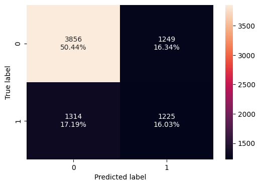

```python
#Calculating different metrics
dtree_model_train_perf=model_performance_classification_sklearn(d_tree,X_train,y_train)
print("Training performance:\n",dtree_model_train_perf)
dtree_model_val_perf=model_performance_classification_sklearn(d_tree,X_test,y_test)
print("Testing performance:\n",dtree_model_val_perf)
#Creating confusion matrix
confusion_matrix_sklearn(d_tree, X_test, y_test)
```

```python
X_train.head()
```

|  | no_of_employees | prevailing_wage | continent_Asia | continent_Europe | continent_North America | continent_Oceania | continent_South America | education_of_employee_Doctorate | education_of_employee_High School | education_of_employee_Master's | has_job_experience_Y | requires_job_training_Y | region_of_employment_Midwest | region_of_employment_Northeast | region_of_employment_South | region_of_employment_West | unit_of_wage_Month | unit_of_wage_Week | unit_of_wage_Year | full_time_position_Y |
| --- | --- | --- | --- | --- | --- | --- | --- | --- | --- | --- | --- | --- | --- | --- | --- | --- | --- | --- | --- | --- |
| 5999 | 1073 | 86487.83 | 1 | 0 | 0 | 0 | 0 | 0 | 0 | 1 | 1 | 0 | 0 | 1 | 0 | 0 | 0 | 0 | 1 | 1 |
| 6788 | 2000 | 19628.24 | 0 | 1 | 0 | 0 | 0 | 0 | 0 | 1 | 1 | 0 | 0 | 0 | 0 | 1 | 0 | 0 | 1 | 1 |
| 22447 | 3521 | 89905.36 | 0 | 1 | 0 | 0 | 0 | 0 | 0 | 1 | 0 | 0 | 0 | 0 | 0 | 1 | 0 | 0 | 1 | 1 |
| 6341 | 1869 | 102972.01 | 1 | 0 | 0 | 0 | 0 | 0 | 0 | 1 | 1 | 0 | 0 | 0 | 0 | 1 | 0 | 0 | 1 | 1 |
| 7871 | 483 | 57757.57 | 1 | 0 | 0 | 0 | 0 | 0 | 1 | 0 | 1 | 1 | 0 | 0 | 1 | 0 | 0 | 0 | 1 | 1 |

```python
# Decision Tree Feature Importance
#pd.Series(d_tree.feature_importances_, index=X_train.columns, columns=["imp"]).sort_values(ascending=False)

feature_imp = pd.DataFrame(d_tree.feature_importances_, index=X_train.columns, columns=["imp"])
feature_imp.sort_values(by="imp", ascending=False)
```

|  | imp |
| --- | --- |
| prevailing_wage | 0.352032 |
| no_of_employees | 0.322787 |
| education_of_employee_High School | 0.069131 |
| has_job_experience_Y | 0.054285 |
| education_of_employee_Master's | 0.024836 |
| continent_Europe | 0.021037 |
| education_of_employee_Doctorate | 0.018708 |
| region_of_employment_Midwest | 0.018491 |
| region_of_employment_South | 0.017722 |
| requires_job_training_Y | 0.015819 |
| full_time_position_Y | 0.015647 |
| continent_North America | 0.014226 |
| region_of_employment_West | 0.013006 |
| continent_Asia | 0.011381 |
| region_of_employment_Northeast | 0.009891 |
| unit_of_wage_Year | 0.009282 |
| continent_South America | 0.005512 |
| continent_Oceania | 0.002285 |
| unit_of_wage_Week | 0.002015 |
| unit_of_wage_Month | 0.001906 |

**Observations:**

1. Prevailing wage and number of employees are higher weightage fields determining the accuracy of visa eligibility.
2. Number of employees is next major field. That means that employer having higher number of employees, applicant having higher prevailing wage and higher education has more chances of getting visa accepted.

It seems the classes are imbalanced.

```python
#Metrics so far. Create empty dataframe
df_metrics = pd.DataFrame(columns=[
    "Accuracy", "Recall", "Precision", "F1",
    "Test/Train/Val", "Model Name", "Data Type", "Model Variable"
    ])
```

```python
def add_metric_row(df_metrics, model_perf, model_name, test_train_val, data_type, model_variable):
    """
    Adds a new row of performance metrics to the DataFrame.

    Parameters:
    df_metrics (pd.DataFrame): The dataframe to which the new row will be added.
    model_perf (pd.DataFrame): The model performance dataframe (train or test performance).
    model_name (str): The name of the model.
    test_train_val (str): The identifier for the data set (Train, Test, or Val).
    data_type (str): The type of data used (Original, Augmented, etc.).
    model_variable (str): The variable name for the model performance dataframe.

    Returns:
    pd.DataFrame: Updated dataframe with the new row.
    """
    # Create a new row dictionary
    new_row = {
        "Accuracy": model_perf.iloc[0, 0],
        "Recall": model_perf.iloc[0, 1],
        "Precision": model_perf.iloc[0, 2],
        "F1": model_perf.iloc[0, 3],
        "Test/Train/Val": test_train_val,
        "Model Name": model_name,
        "Data Type": data_type,
        "Model Variable": model_variable
    }

    # Add the new row to the dataframe
    df_metrics.loc[len(df_metrics)] = new_row
    return df_metrics
```

```python
df_metrics = add_metric_row(df_metrics, dtree_model_train_perf, "Decision Tree", "Train", "Original", "dtree_model_train_perf")
df_metrics = add_metric_row(df_metrics, dtree_model_val_perf, "Decision Tree", "Validation", "Original", "dtree_model_val_perf")
df_metrics
```

|  | Accuracy | Recall | Precision | F1 | Test/Train/Val | Model Name | Data Type | Model Variable |
| --- | --- | --- | --- | --- | --- | --- | --- | --- |
| 0 | 1.000000 | 1.000000 | 1.00000 | 1.000000 | Train | Decision Tree | Original | dtree_model_train_perf |
| 1 | 0.664704 | 0.482473 | 0.49515 | 0.488729 | Validation | Decision Tree | Original | dtree_model_val_perf |

** Random Forest **

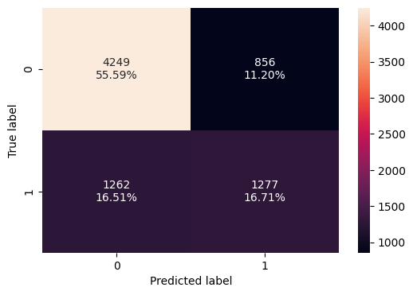

```python
#Fitting the model
rf_estimator = RandomForestClassifier(random_state=1)
rf_estimator.fit(X_train,y_train)

#Calculating different metrics
rf_estimator_model_train_perf=model_performance_classification_sklearn(rf_estimator,X_train,y_train)
rf_estimator_model_val_perf=model_performance_classification_sklearn(rf_estimator,X_test,y_test)
#Creating confusion matrix
confusion_matrix_sklearn(rf_estimator, X_test, y_test)
```